# Exploratory Analysis

Group: Padma Gundapaneni, Ayush Banwari, Zikai Song, Thomas Lee

This report details our exploratory analysis of the “Length of hospital stay” health care utilization dataset from OECD. We examined the distribution of variables and examined the relationships between variables. The variables we looked at are the average length of hospital stay, country, and year.

## Distribution of Variables

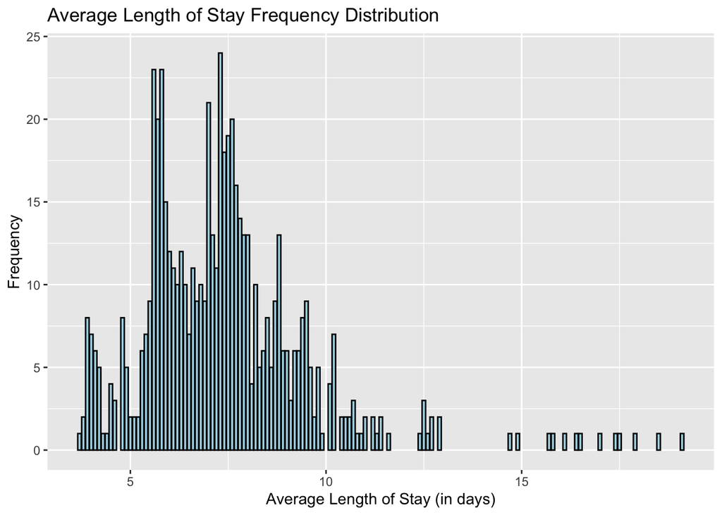

In the plot above, we can see the distribution of the variable ‘Average Hospital Stay Length’. The dataset provides the average hospital stay length per country for a range of almost 20 years. As can be seen in the graph, the average stay length ranges from 4 to around 20 days The most common average length of stay is between 6 and 8 days. There are few occurrences of an average hospital stay length of 10 days or more.

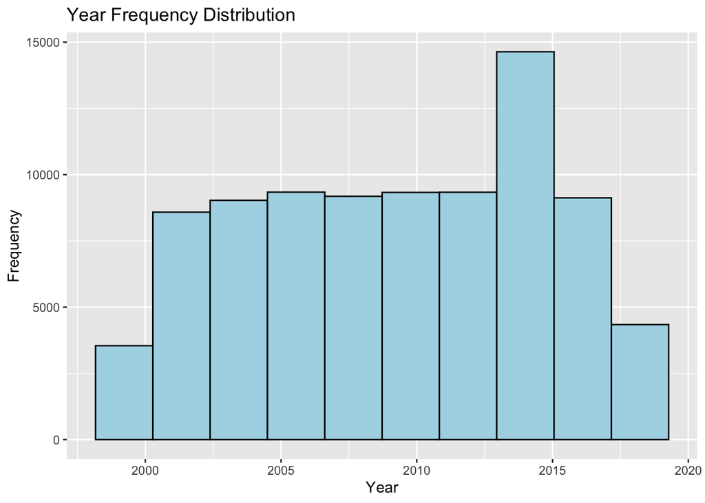

In the plot above, we can observe that there seems to be outlier at the tail ends of the data sets. In addition, for the most part, there is more data around the year 2015. This means that the dataset contains a lot of data in the year 2015. For the most part, however, the data seems to be evenly distributed to include data from the entire range. It is also important to note that data is included from the year 2000-2019.

## Relationships between Variables

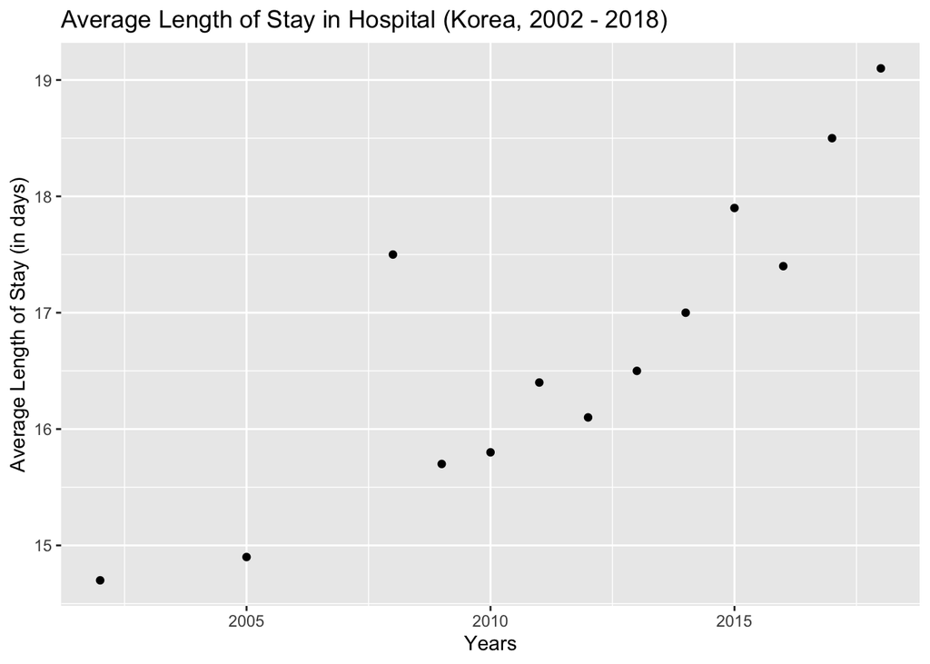

In the plot above, we can observe that the average length of stay in hospital generally increases over time in Korea from 2002 to 2018. This could have resulted from the increased risk of infection and medication side effects or decreased cost of hospitalization. The sudden increase in 2008 could have occurred from the mad cow disease, or bovine spongiform encephalopathy, which caused numerous hospitalizations.

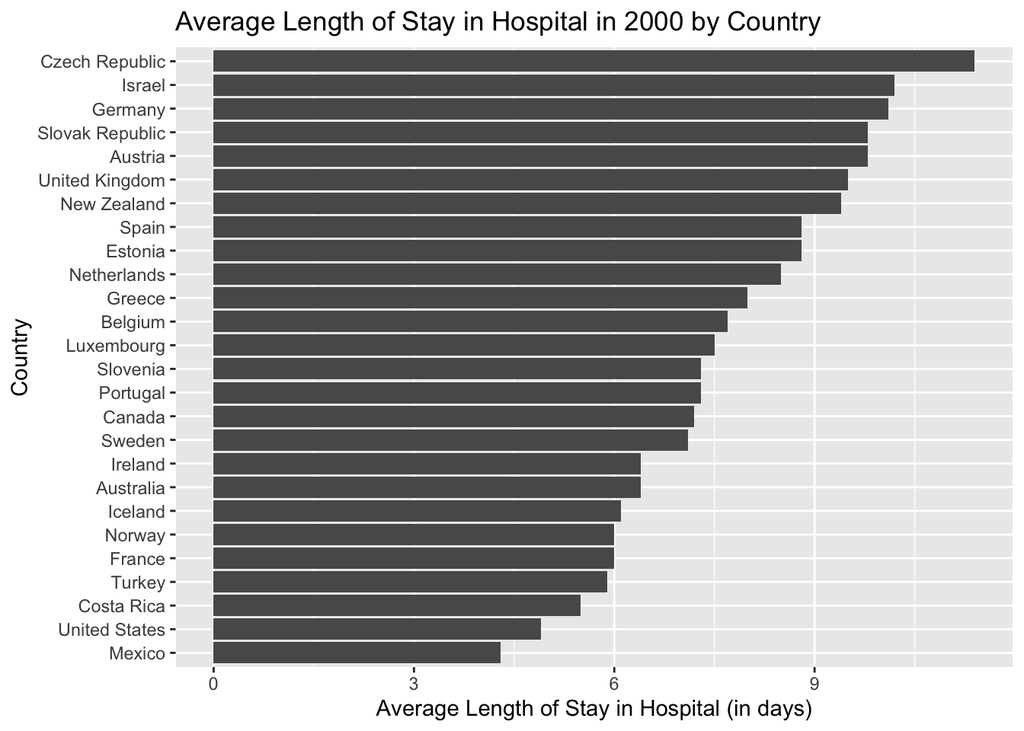

From the graph, we discovered that the Czech Republic has the longest average length in the hospital in 2000, and Mexico has the lowest average length in hospital in 2000. Average length in hospital is linked to many factors, such as price of medical service, medical resources, and public health conditions. Simply looking at the average length in hospital cannot give us a overview of the public health conditions of the countries.